# Part II - Prosper Loan Data Insights

## Debt-to-Income Ratio by Loan Status and Income Range

This plot shows the relationship between Debt-to-Income Ratio, Loan Status, and Income Range using boxplots. Debt-to-Income Ratio is plotted on the x-axis and Loan Status on the y-axis. Each box represents the distribution of Debt-to-Income Ratio for a particular Income Range within a Loan Status category. The height of each box represents the range of Loan Status values for each category. The blue color of the boxes represents the Income Range.

From the plot, we can observe that the Debt-to-Income Ratio tends to be higher for Loan Status categories such as Chargedoff and Defaulted, as compared to Completed loans. Additionally, we can see that the higher the Income Range, the lower the Debt-to-Income Ratio tends to be. This suggests that borrowers with higher incomes tend to have lower debt-to-income ratios.

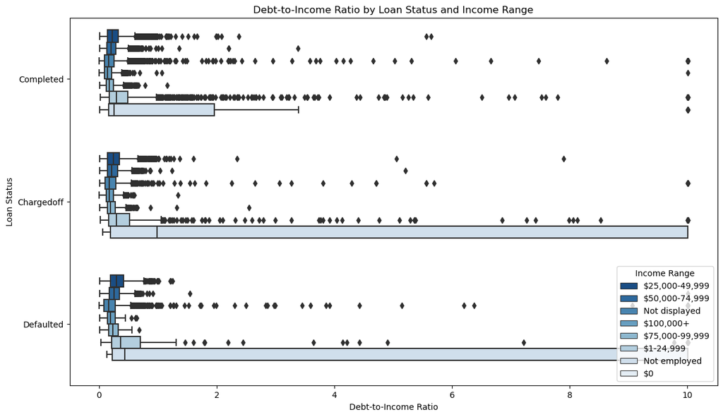

## Relationship between Prosper rating, loan amount, and loan status

The above visualization is a scatterplot showing the relationship between Prosper rating, loan amount, and loan status. The y-axis represents the Prosper rating, which is a measure of a borrower's creditworthiness, while the x-axis represents the loan amount. The dots on the plot represent individual loans, and they are color-coded based on their loan status.

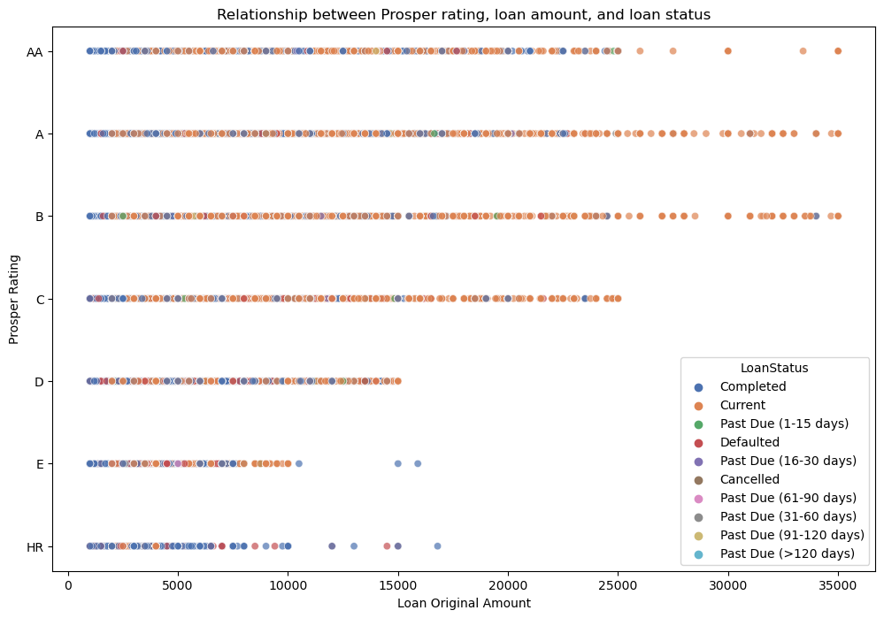